# Analyze A/B Test Results

The following are excerpts of a guided assignment I completed for a Udacity class. The process, layout, and much of the commentary are not my own; they are the work of Udacity instructors. While much of it is not my work, the calculations are my own. I'm publishing this project both as a reference for future projects and as a demonstration of my experience completing A/B testing.

- Introduction
- Part I - Probability
- Part II - A/B Test
- Part III - Regression
- Final Check
- Submission

## Part I - Probability

To get started, let's import our libraries.

```python
import pandas as pd
import numpy as np
import random
import matplotlib.pyplot as plt
%matplotlib inline
#We are setting the seed to assure you get the same answers on quizzes as we set up
random.seed(42)
pd.options.mode.chained_assignment = None  # default='warn' #suppress settingwithcopywarning messages
```

### ToDo 1.1

**a.** Read in the dataset from the `ab_data.csv` file and take a look at the top few rows here:

```python
df=pd.read_csv('ab_data.csv')
df.head()
```

|  | user_id | timestamp | group | landing_page | converted |
| --- | --- | --- | --- | --- | --- |
| 0 | 851104 | 2017-01-21 22:11:48.556739 | control | old_page | 0 |
| 1 | 804228 | 2017-01-12 08:01:45.159739 | control | old_page | 0 |
| 2 | 661590 | 2017-01-11 16:55:06.154213 | treatment | new_page | 0 |
| 3 | 853541 | 2017-01-08 18:28:03.143765 | treatment | new_page | 0 |
| 4 | 864975 | 2017-01-21 01:52:26.210827 | control | old_page | 1 |

### ToDo 1.2

**a.** Now use the answer to the quiz to create a new dataset that meets the specifications from the quiz. Store your new dataframe in **df2**.

```python
# Remove the inaccurate rows, and store the result in a new dataframe df2
# Instead, this operation copies the accurate rows into df2.
df2 = df[((df["group"] == "control") & (df["landing_page"] == "old_page")) |
           ((df["group"] == "treatment") & (df["landing_page"] == "new_page"))]
```

```python
# Double Check all of the incorrect rows were removed from df2 -
# Output of the statement below should be 0
df2[((df2['group'] == 'treatment') == (df2['landing_page'] == 'new_page')) == False].shape[0]
```

```
0
```

### ToDo 1.3

Use **df2** and the cells below to answer questions for **Quiz 3** in the classroom.

**c.** Display the rows for the duplicate **user_id**?

```python
df2.loc[df2['user_id'] == 773192]
```

|  | user_id | timestamp | group | landing_page | converted |
| --- | --- | --- | --- | --- | --- |
| 1899 | 773192 | 2017-01-09 05:37:58.781806 | treatment | new_page | 0 |
| 2893 | 773192 | 2017-01-14 02:55:59.590927 | treatment | new_page | 0 |

**d.** Remove **one** of the rows with a duplicate **user_id**, from the **df2** dataframe.

```python
# Remove one of the rows with a duplicate user_id..
# Hint: The dataframe.drop_duplicates() may not work in this case because the rows with duplicate user_id are not entirely identical.
df2.drop(index=1899, inplace=True)
# Check again if the row with a duplicate user_id is deleted or not
df2.loc[df2['user_id'] == 773192]
```

|  | user_id | timestamp | group | landing_page | converted |
| --- | --- | --- | --- | --- | --- |
| 2893 | 773192 | 2017-01-14 02:55:59.590927 | treatment | new_page | 0 |

### ToDo 1.4

Use **df2** in the cells below to answer the quiz questions related to **Quiz 4** in the classroom.

**a.** What is the probability of an individual converting regardless of the page they receive?

```python
(df2[df2["converted"] == 1]['converted'].sum())/len(df2) #converted users / total users
```

```
0.11959708724499628
```

**b.** Given that an individual was in the `control` group, what is the probability they converted?

```python
#method 1: get all stats using groupby
df2.groupby(['group'])['converted'].value_counts(normalize = True)
```

```
group      converted
control    0            0.879614
           1            0.120386
treatment  0            0.881192
           1            0.118808
Name: proportion, dtype: float64
```

```python
#method 2: get specific stat using brackets
ctrl_conversion = (df2[(df2["group"] == 'control') & (df2["converted"] == 1)]['user_id'].count()/
df2[df2["group"] == 'control']['user_id'].count())
ctrl_conversion
```

```
0.1203863045004612
```

**c.** Given that an individual was in the `treatment` group, what is the probability they converted?

```python
treatment_conversion = (df2[(df2["group"] == 'treatment') & (df2["converted"] == 1)]['user_id'].count()/
df2[df2["group"] == 'treatment']['user_id'].count())
treatment_conversion
```

```
0.11880806551510564
```

The probabilities you've computed in the points (b). and (c). above can also be treated as conversion rate. Calculate the actual difference (`obs_diff`) between the conversion rates for the two groups. You will need that later.

```python
# Calculate the actual difference (obs_diff) between the conversion rates for the two groups.
obs_diff = treatment_conversion - ctrl_conversion
obs_diff
```

```
-0.0015782389853555567
```

**d.** What is the probability that an individual received the new page?

```python
len(df2[df2["group"] == 'treatment']) / len(df2)
```

```
0.5000619442226688
```

**e.** Consider your results from parts (a) through (d) above, and explain below whether the new `treatment` group users lead to more conversions.

Based on the data so far, there is not support for the hypothesis that being in the treatment group will lead to more conversions. The control group is 12.04% likely to convert, while the treatment group is 11.89% likely to convert, so the control group is more likely to convert than the treatment group. The difference is so small -- 0.16% -- that it's unlikely to be meaningful.

## Part II - A/B Test

### ToDo 2.1

If you want to assume that the old page is better unless the new page proves to be definitely better at a Type I error rate of 5%, what should be your null and alternative hypotheses (**$H_0$** and **$H_1$**)?

You can state your hypothesis in terms of words or in terms of **$p_{old}$** and **$p_{new}$**, which are the "converted" probability (or rate) for the old and new pages respectively.

𝐻0: 𝑝𝑜𝑙𝑑 >= 𝑝𝑛𝑒𝑤  
𝐻1: 𝑝𝑜𝑙𝑑 < 𝑝𝑛𝑒𝑤

### ToDo 2.2 - Null Hypothesis $H_0$ Testing

Under the null hypothesis $H_0$, assume that $p_{new}$ and $p_{old}$ are equal. Furthermore, assume that $p_{new}$ and $p_{old}$ both are equal to the **converted** success rate in the `df2` data regardless of the page. So, our assumption is:

$p_{new}$ = $p_{old}$ = $p_{population}$

**a.** What is the **conversion rate** for $p_{new}$ under the null hypothesis?

```python
pnew = (df2[df2["converted"] == 1]['converted'].sum())/len(df2) #same as population conversion rate
pnew
```

```
0.11959708724499628
```

**b.** What is the **conversion rate** for $p_{old}$ under the null hypothesis?

```python
pold = (df2[df2["converted"] == 1]['converted'].sum())/len(df2) #same as population conversion rate
pold
```

```
0.11959708724499628
```

**c.** What is $n_{new}$, the number of individuals in the treatment group?

```python
nnew = len(df2[df2["group"] == 'treatment'])
nnew
```

```
145310
```

**d.** What is $n_{old}$, the number of individuals in the control group?

```python
nold = len(df2[df2["group"] == 'control'])
nold
```

```
145274
```

```python
#pnew - pold:
pdiff = pnew - pold
pdiff
```

```
0.0
```

**e. Simulate Sample for the `treatment` Group**  
Simulate $n_{new}$ transactions with a conversion rate of $p_{new}$ under the null hypothesis.

```python
# Simulate a Sample for the treatment Group
#Take a random user in the treatment group nnew times
new_page_converted = np.random.choice(df2[df2["group"] == 'treatment']['converted'], nnew)
new_page_converted.mean()
```

```
0.11968894088500448
```

**f. Simulate Sample for the `control` Group**  
Simulate $n_{old}$ transactions with a conversion rate of $p_{old}$ under the null hypothesis.  
Store these $n_{old}$ 1's and 0's in the `old_page_converted` numpy array.

```python
# Simulate a Sample for the control Group
#Take a random user in the control group nold times
old_page_converted = np.random.choice(df2[df2["group"] == 'control']['converted'], nold)
old_page_converted.mean()
```

```
0.11991133995071382
```

**g.** Find the difference in the "converted" probability $(p{'}_{new}$ - $p{'}_{old})$ for your simulated samples from the parts (e) and (f) above.

```python
sample_diffs = new_page_converted.mean() - old_page_converted.mean()
sample_diffs
```

```
-0.00022239906570933887
```

**h. Sampling distribution**  
Re-create `new_page_converted` and `old_page_converted` and find the $(p{'}_{new}$ - $p{'}_{old})$ value 10,000 times using the same simulation process you used in parts (a) through (g) above.

Store all $(p{'}_{new}$ - $p{'}_{old})$ values in a NumPy array called `p_diffs`.

```python
# Sampling distribution
p_diffs = []
new_page_converted = df2[df2["group"] == 'treatment']['converted']
old_page_converted = df2[df2["group"] == 'control']['converted']
for _ in range(10000):
    new_sample = np.random.choice(new_page_converted, nnew)
    old_sample = np.random.choice(old_page_converted, nold)
    p_diffs.append(new_sample.mean() - old_sample.mean())
p_diffs = np.array(p_diffs)
```

**i. Histogram**  
Plot a histogram of the **p_diffs**. Does this plot look like what you expected? Use the matching problem in the classroom to assure you fully understand what was computed here.

Also, use `plt.axvline()` method to mark the actual difference observed in the `df2` data (recall `obs_diff`), in the chart.

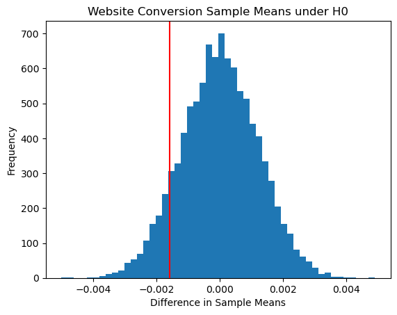

```python
p_diffs_centered = p_diffs - p_diffs.mean() #Center the sample distribution on null (0)
plt.hist(p_diffs_centered, bins=50);
plt.axvline(x=obs_diff, color='red');
plt.xlabel('Difference in Sample Means');
plt.ylabel('Frequency');
plt.title('Website Conversion Sample Means under H0');
```

**j.** What proportion of the **p_diffs** are greater than the actual difference observed in the `df2` data?

```python
#proportion = number of p_diffs greater than obs_diff, divided by total amount of p_diffs (which is 10,000)
len(p_diffs_centered[p_diffs_centered > obs_diff])/10000
```

```
0.8994
```

**l. Using Built-in Methods for Hypothesis Testing**  
We could also use a built-in to achieve similar results. Though using the built-in might be easier to code, the above portions are a walkthrough of the ideas that are critical to correctly thinking about statistical significance.

Fill in the statements below to calculate the:

- `convert_old`: number of conversions with the old_page
- `convert_new`: number of conversions with the new_page
- `n_old`: number of individuals who were shown the old_page
- `n_new`: number of individuals who were shown the new_page

```python
import statsmodels.api as sm

# number of conversions with the old_page
convert_old = len(df2[(df2["group"] == 'control') & (df2["converted"] == 1)]['user_id'])

# number of conversions with the new_page
convert_new = len(df2[(df2["group"] == 'treatment') & (df2["converted"] == 1)]['user_id'])

# number of individuals who were shown the old_page
n_old = len(df2[df2["group"] == 'control']['user_id'])

# number of individuals who received new_page
n_new = len(df2[df2["group"] == 'treatment']['user_id'])
```

```python
import statsmodels.api as sm
# Complete the sm.stats.proportions_ztest() method arguments
z_score, p_value = sm.stats.proportions_ztest(count=[convert_new, convert_old], nobs=[n_new, n_old], value=0, alternative='larger')
print(z_score, p_value)
#arguments:
#count is an array of the number of conversions in our two samples
#nobs is an array of the number of tests in our two samples
#values is the hypothetical difference in the mean of our samples. Assuming H0 is true, the difference is 0.
#alternative is larger because H1 is that p_new > p_old
```

```
-1.3109241984234394 0.9050583127590245
```

### Part III - A regression approach

### ToDo 3.1

In this final part, you will see that the result you achieved in the A/B test in Part II above can also be achieved by performing regression.

**a.** Since each row in the `df2` data is either a conversion or no conversion, what type of regression should you be performing in this case?

Logistic regression!

**b.** The goal is to use **statsmodels** library to fit the regression model you specified in part **a.** above to see if there is a significant difference in conversion based on the page-type a customer receives. However, you first need to create the following two columns in the `df2` dataframe:

1. `intercept` - It should be `1` in the entire column.
2. `ab_page` - It's a dummy variable column, having a value `1` when an individual receives the **treatment**, otherwise `0`.

```python
df2.head(2)
```

|  | user_id | timestamp | group | landing_page | converted |
| --- | --- | --- | --- | --- | --- |
| 0 | 851104 | 2017-01-21 22:11:48.556739 | control | old_page | 0 |
| 1 | 804228 | 2017-01-12 08:01:45.159739 | control | old_page | 0 |

```python
df2['intercept'] = 1
df2[['ab_page']] = pd.get_dummies(df['group'], drop_first=True, dtype=int) #get_dummies requires 2 new columns; one will be dropped
df2.head()
```

|  | user_id | timestamp | group | landing_page | converted | intercept | ab_page |
| --- | --- | --- | --- | --- | --- | --- | --- |
| 0 | 851104 | 2017-01-21 22:11:48.556739 | control | old_page | 0 | 1 | 0 |
| 1 | 804228 | 2017-01-12 08:01:45.159739 | control | old_page | 0 | 1 | 0 |
| 2 | 661590 | 2017-01-11 16:55:06.154213 | treatment | new_page | 0 | 1 | 1 |
| 3 | 853541 | 2017-01-08 18:28:03.143765 | treatment | new_page | 0 | 1 | 1 |
| 4 | 864975 | 2017-01-21 01:52:26.210827 | control | old_page | 1 | 1 | 0 |

**c.** Use **statsmodels** to instantiate your regression model on the two columns you created in part (b). above, then fit the model to predict whether or not an individual converts.

```python
logit_mod = sm.Logit(df2['converted'], df2[['intercept', 'ab_page']])
results = logit_mod.fit()
```

```
Optimization terminated successfully.
         Current function value: 0.366118
         Iterations 6
```

**d.** Provide the summary of your model below, and use it as necessary to answer the following questions.

```python
results.summary2()
```

| Model: | Logit | Method: | MLE |
| --- | --- | --- | --- |
| Dependent Variable: | converted | Pseudo R-squared: | 0.000 |
| Date: | 2024-12-03 18:02 | AIC: | 212780.3502 |
| No. Observations: | 290584 | BIC: | 212801.5095 |
| Df Model: | 1 | Log-Likelihood: | -1.0639e+05 |
| Df Residuals: | 290582 | LL-Null: | -1.0639e+05 |
| Converged: | 1.0000 | LLR p-value: | 0.18988 |
| No. Iterations: | 6.0000 | Scale: | 1.0000 |

|  | Coef. | Std.Err. | z | P>\|z\| | [0.025 | 0.975] |
| --- | --- | --- | --- | --- | --- | --- |
| intercept | -1.9888 | 0.0081 | -246.6690 | 0.0000 | -2.0046 | -1.9730 |
| ab_page | -0.0150 | 0.0114 | -1.3109 | 0.1899 | -0.0374 | 0.0074 |

**e.** What is the p-value associated with **ab_page**? Why does it differ from the value you found in **Part II**?

**f.** Now, you are considering other things that might influence whether or not an individual converts. Discuss why it is a good idea to consider other factors to add into your regression model. Are there any disadvantages to adding additional terms into your regression model?

The big advantage of adding other factors into the regression model is that it can make the model more accurate. For example, if conversion is affected by the time of day a website is accessed, it might be nice to know that, and including it in our model will help us better predict which subset of users is more likely to convert.

Some drawbacks of adding more factors are increasing the model's complexity and obscuring how much other factors affect the dependent variable. One example from our coursework is when we used both the size of a house and the number of bathrooms to predict a house's value. Because those independent variables were actually dependent on each other, including both of them in our model made it difficult to interpret the results of our model, and they made each other seem less impactful on the value of the house.

**g. Adding countries**  
Now along with testing if the conversion rate changes for different pages, also add an effect based on which country a user lives in.

1. You will need to read in the **countries.csv** dataset and merge together your `df2` datasets on the appropriate rows. You call the resulting dataframe `df_merged`. [Here](https://pandas.pydata.org/pandas-docs/stable/reference/api/pandas.DataFrame.join.html) are the docs for joining tables.
2. Does it appear that country had an impact on conversion? To answer this question, consider the three unique values, `['UK', 'US', 'CA']`, in the `country` column. Create dummy variables for these country columns.

Provide the statistical output as well as a written response to answer this question.

```python
# Read the countries.csv
countries = pd.read_csv('countries.csv')
countries.head(2)
```

|  | user_id | country |
| --- | --- | --- |
| 0 | 834778 | UK |
| 1 | 928468 | US |

```python
df2.head(2) #remind myself of what's in df2
```

|  | user_id | timestamp | group | landing_page | converted | intercept | ab_page |
| --- | --- | --- | --- | --- | --- | --- | --- |
| 0 | 851104 | 2017-01-21 22:11:48.556739 | control | old_page | 0 | 1 | 0 |
| 1 | 804228 | 2017-01-12 08:01:45.159739 | control | old_page | 0 | 1 | 0 |

```python
# Join country with df2 on the user_id column
df_merged = df2.set_index('user_id').join(countries.set_index('user_id'))
df_merged.head(2)
```

| user_id | timestamp | group | landing_page | converted | intercept | ab_page | country |
| --- | --- | --- | --- | --- | --- | --- | --- |
| 851104 | 2017-01-21 22:11:48.556739 | control | old_page | 0 | 1 | 0 | US |
| 804228 | 2017-01-12 08:01:45.159739 | control | old_page | 0 | 1 | 0 | US |

```python
# Create the necessary dummy variables
df_merged[['CA', 'UK', 'US']] = pd.get_dummies(df_merged['country'], dtype=int)
df_merged.head(10) #make sure dummies were added to the right columns
```

| user_id | timestamp | group | landing_page | converted | intercept | ab_page | country | CA | UK | US |
| --- | --- | --- | --- | --- | --- | --- | --- | --- | --- | --- |
| 851104 | 2017-01-21 22:11:48.556739 | control | old_page | 0 | 1 | 0 | US | 0 | 0 | 1 |
| 804228 | 2017-01-12 08:01:45.159739 | control | old_page | 0 | 1 | 0 | US | 0 | 0 | 1 |
| 661590 | 2017-01-11 16:55:06.154213 | treatment | new_page | 0 | 1 | 1 | US | 0 | 0 | 1 |
| 853541 | 2017-01-08 18:28:03.143765 | treatment | new_page | 0 | 1 | 1 | US | 0 | 0 | 1 |
| 864975 | 2017-01-21 01:52:26.210827 | control | old_page | 1 | 1 | 0 | US | 0 | 0 | 1 |
| 936923 | 2017-01-10 15:20:49.083499 | control | old_page | 0 | 1 | 0 | US | 0 | 0 | 1 |
| 679687 | 2017-01-19 03:26:46.940749 | treatment | new_page | 1 | 1 | 1 | CA | 1 | 0 | 0 |
| 719014 | 2017-01-17 01:48:29.539573 | control | old_page | 0 | 1 | 0 | US | 0 | 0 | 1 |
| 817355 | 2017-01-04 17:58:08.979471 | treatment | new_page | 1 | 1 | 1 | UK | 0 | 1 | 0 |
| 839785 | 2017-01-15 18:11:06.610965 | treatment | new_page | 1 | 1 | 1 | CA | 1 | 0 | 0 |

```python
# Fitting a model with *just* the country factors
import statsmodels.api as sm #used during testing
logit_mod = sm.Logit(df_merged['converted'], df_merged[['intercept', 'ab_page', 'CA', 'UK']])
results2 = logit_mod.fit()
results2.summary2()
```

```
Optimization terminated successfully.
         Current function value: 0.366113
         Iterations 6
```

| Model: | Logit | Method: | MLE |
| --- | --- | --- | --- |
| Dependent Variable: | converted | Pseudo R-squared: | 0.000 |
| Date: | 2024-12-03 18:04 | AIC: | 212781.1253 |
| No. Observations: | 290584 | BIC: | 212823.4439 |
| Df Model: | 3 | Log-Likelihood: | -1.0639e+05 |
| Df Residuals: | 290580 | LL-Null: | -1.0639e+05 |
| Converged: | 1.0000 | LLR p-value: | 0.17599 |
| No. Iterations: | 6.0000 | Scale: | 1.0000 |

|  | Coef. | Std.Err. | z | P>\|z\| | [0.025 | 0.975] |
| --- | --- | --- | --- | --- | --- | --- |
| intercept | -1.9893 | 0.0089 | -223.7628 | 0.0000 | -2.0067 | -1.9718 |
| ab_page | -0.0149 | 0.0114 | -1.3069 | 0.1912 | -0.0374 | 0.0075 |
| CA | -0.0408 | 0.0269 | -1.5161 | 0.1295 | -0.0934 | 0.0119 |
| UK | 0.0099 | 0.0133 | 0.7433 | 0.4573 | -0.0162 | 0.0359 |

According to these results, the users' countries are not statistically significant factors in the conversion rate. Both countries have p-values greater than 0.05, so we can't consider either of these factors to be statistically significant. If we found a factor that was significant, we could interpret its effect on conversion by taking the exponent of its coefficient. For example, if residence in Canada were found to be a significant factor, we would take the exponent of its coefficient (or in this case, the inverse of that exponent) as follows:

```python
print('CA Coefficient: ', 1/np.exp(-0.0408))
print('UK Coefficient: ', np.exp(0.0099))
```

```
CA Coefficient:  1.0416437559600236
UK Coefficient:  1.0099491671175422
```

We then interpret the result as follows: if a user is in Canada, he is 1.04 times less likely (because the coefficient is negative) to convert than he would be if he were in the U.S., holding all other factors constant. Being in the UK has even less of an effect.

This is just to display an understanding of interpreting coefficients in logistic regression. In this case, a user's country isn't a significant factor in whether he converts, so interpreting those coefficients is not very meaningful.

**h. Fit your model and obtain the results**  
Though you have now looked at the individual factors of country and page on conversion, we would now like to look at an interaction between page and country to see if are there significant effects on conversion. **Create the necessary additional columns, and fit the new model.**

Provide the summary results (statistical output), and your conclusions (written response) based on the results.

```python
#First, create interaction series:
df_merged['CA_inter'] = df_merged['CA']*df_merged['ab_page']
df_merged['UK_inter'] = df_merged['UK']*df_merged['ab_page']
#I didn't create an interaction series between the U.S. and ab_page because that will be the intercept
```

```python
# Fit your model, and summarize the results
#import statsmodels.api as sm #used during testing
logit_mod = sm.Logit(df_merged['converted'], df_merged[['intercept', 'ab_page', 'CA', 'UK', 'CA_inter', 'UK_inter']])
results3 = logit_mod.fit()
results3.summary2()
```

```
Optimization terminated successfully.
         Current function value: 0.366109
         Iterations 6
```

| Model: | Logit | Method: | MLE |
| --- | --- | --- | --- |
| Dependent Variable: | converted | Pseudo R-squared: | 0.000 |
| Date: | 2024-12-03 18:04 | AIC: | 212782.6602 |
| No. Observations: | 290584 | BIC: | 212846.1381 |
| Df Model: | 5 | Log-Likelihood: | -1.0639e+05 |
| Df Residuals: | 290578 | LL-Null: | -1.0639e+05 |
| Converged: | 1.0000 | LLR p-value: | 0.19199 |
| No. Iterations: | 6.0000 | Scale: | 1.0000 |

|  | Coef. | Std.Err. | z | P>\|z\| | [0.025 | 0.975] |
| --- | --- | --- | --- | --- | --- | --- |
| intercept | -1.9865 | 0.0096 | -206.3440 | 0.0000 | -2.0053 | -1.9676 |
| ab_page | -0.0206 | 0.0137 | -1.5052 | 0.1323 | -0.0473 | 0.0062 |
| CA | -0.0175 | 0.0377 | -0.4652 | 0.6418 | -0.0914 | 0.0563 |
| UK | -0.0057 | 0.0188 | -0.3057 | 0.7598 | -0.0426 | 0.0311 |
| CA_inter | -0.0469 | 0.0538 | -0.8718 | 0.3833 | -0.1523 | 0.0585 |
| UK_inter | 0.0314 | 0.0266 | 1.1807 | 0.2377 | -0.0207 | 0.0835 |

Again, neither of the new factors we tested are statistically significant. Each factor has a p-value greater than 0.05, so we can't consider interactions between country and treatment page to be statistically signifcant. If they were significant, interpreting their coefficients would be less straightforward than with terms that aren't interactive.

Finally, the practical conclusion of these tests is to keep the website the same. We have failed to prove that the current website performs worse than the new one. We have also failed to prove that a user's country of origin is a factor in conversion, so we must also conclude that it isn't worth considering at the moment.